# Starwars community detection

### 1.6.5 Edge betweenness community detection

This method bases the community detection on the edge betweenness of the set of edges in the network. The computational cost derived by the calculations performed are a little bit higher for this network but not as high as the optimal modularity, therefore, it is a method that turns to be viable for this network. The results show a modularity smaller than the rest of methods with a value of just 0.3456 considering a K equal to 6.

The partition suggested by this method involves two large communities of size 58 and 42, and four smaller ones of sizes 4, 3 and 1. The largest community harbors characters like Darth Vader, Qui-Gon, Obi-Wan, Emperor, Jabba, just to main the most important ones considering some of the results of the previous assignment, and also based on the characters that were part of the maximal size clique. Moreover, the second largest includes Leia, Han, Luke Chewbacca, among others. The smallest one is just conformed by Gold Five, and the rest of characters in the remaining communities appear to be some less connected characters.

```r
Start_time <- Sys.time()
sw.network.eb <- cluster_edge_betweenness(sw.network,directed=FALSE)
sw.network.eb
```

```
## IGRAPH clustering edge betweenness, groups: 6, mod: 0.35
## + groups:
##   $`1`
##    [1] "DARTH VADER"          "R2-D2"                "QUI-GON"
##    [4] "NUTE GUNRAY"          "PK-4"                 "TC-14"
##    [7] "OBI-WAN"              "DOFINE"               "RUNE"
##   [10] "TEY HOW"              "EMPEROR"              "CAPTAIN PANAKA"
##   [13] "SIO BIBBLE"           "JAR JAR"              "TARPALS"
##   [16] "BOSS NASS"            "PADME"                "RIC OLIE"
##   [19] "WATTO"                "SEBULBA"              "JIRA"
##   [22] "SHMI"                 "DARTH MAUL"           "KITSTER"
##   [25] "WALD"                 "FODE/BEED"            "JABBA"
##   + ... omitted several groups/vertices
```

```r
End_time <- Sys.time()

print(paste('Time elapsed: ', (End_time-Start_time)))
```

```
## [1] "Time elapsed:  0.954445838928223"
```

```r
length(sw.network.eb)
```

```
## [1] 6
```

```r
sizes(sw.network.eb)
```

```
## Community sizes
##  1  2  3  4  5  6
## 58 42  3  1  3  4
```

```r
membership(sw.network.eb)
```

```
##          DARTH VADER                R2-D2            CHEWBACCA
##                    1                    1                    2
##                 BB-8              QUI-GON          NUTE GUNRAY
##                    2                    1                    1
##                 PK-4                TC-14              OBI-WAN
##                    1                    1                    1
##               DOFINE                 RUNE              TEY HOW
##                    1                    1                    1
##              EMPEROR       CAPTAIN PANAKA           SIO BIBBLE
##                    1                    1                    1
##              JAR JAR              TARPALS            BOSS NASS
##                    1                    1                    1
##                PADME             RIC OLIE                WATTO
##                    1                    1                    1
##              SEBULBA                 JIRA                 SHMI
##                    1                    1                    1
##                C-3PO           DARTH MAUL              KITSTER
##                    2                    1                    1
##                 WALD            FODE/BEED                JABBA
##                    1                    1                    1
##               GREEDO              VALORUM           MACE WINDU
##                    1                    1                    1
##         KI-ADI-MUNDI                 YODA                 RABE
##                    1                    1                    1
##          BAIL ORGANA         GENERAL CEEL            BRAVO TWO
##                    1                    1                    1
##          BRAVO THREE        CAPTAIN TYPHO      SENATOR ASK AAK
##                    1                    1                    1
##         ORN FREE TAA                 SOLA                JOBAL
##                    1                    1                    1
##                RUWEE              TAUN WE              LAMA SU
##                    1                    3                    3
##            BOBA FETT           JANGO FETT                 OWEN
##                    2                    3                    1
##                 BERU               CLIEGG          COUNT DOOKU
##                    2                    1                    1
##              SUN RIT               POGGLE             PLO KOON
##                    1                    1                    1
##             ODD BALL     GENERAL GRIEVOUS             FANG ZAR
##                    1                    1                    1
```

[output cut: 19 more lines]

```
##                    2                    1                    2
##               BOUSHH       ADMIRAL ACKBAR        LOR SAN TEKKA
##                    2                    2                    2
##                  POE             KYLO REN       CAPTAIN PHASMA
##                    2                    2                    2
##                 FINN          UNKAR PLUTT                  REY
##                    2                    2                    2
##          GENERAL HUX    LIEUTENANT MITAKA             BALA-TIK
##                    6                    6                    2
##                SNOKE                  MAZ                 SNAP
##                    6                    2                    2
##      ADMIRAL STATURA            YOLO ZIFF        COLONEL DATOO
##                    2                    2                    6
##            ELLO ASTY                 JESS              NIV LEK
##                    2                    2                    2
```

```r
modularity(sw.network.eb)
```

```
## [1] 0.3456612
```

```r
method.compare[5,1]<- modularity(sw.network.eb)
method.compare[5,2]<- length(sizes(sw.network.eb))
method.compare[5,3]<-(End_time-Start_time)
```

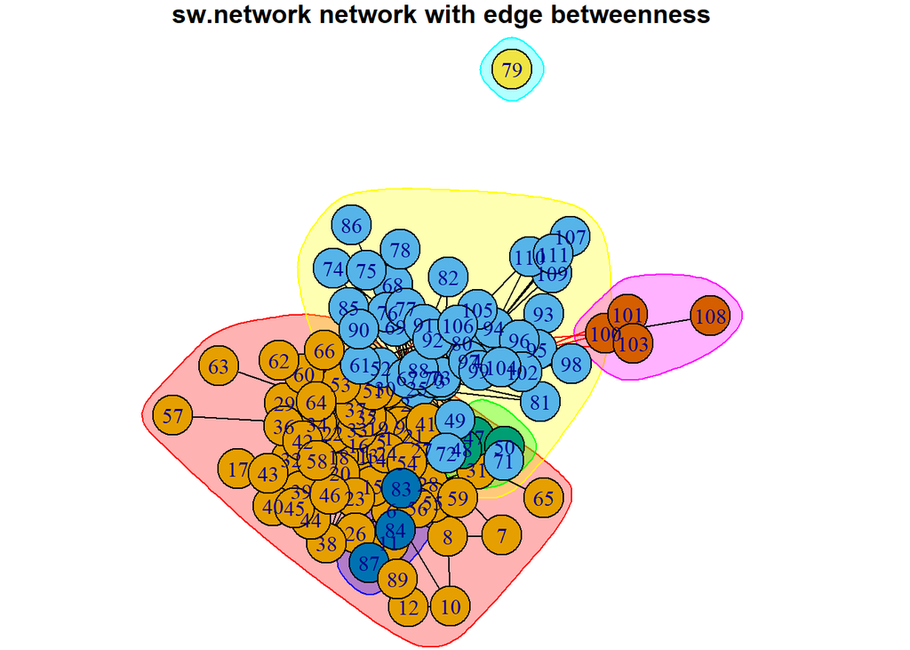

```r
par(mar=c(0,0,1,1))
plot(sw.network.eb,
     sw.network,
     vertex.color=membership(sw.network.fg),
     vertex.label=seq(1:111),
     #vertex.label=NA,
     main="sw.network network with edge betweenness")
```